# CFB Analytics — Data & Model Evaluation

A polyglot college-football pipeline · CFBD → DuckDB → dbt → R + Python models

Published

July 2, 2026

> **Data:** [CollegeFootballData.com](https://collegefootballdata.com) (CFBD API, free tier). Raw data is gitignored and collected within the API’s bounded/cached terms. This page evaluates **(1) the data** and **(2) the models’ accuracy**. Every statistical method is implemented in **both R and Python** against the same warehouse feed; their agreement is a built-in correctness check (see *R ↔︎ Python parity*).

🏈 **Open the interactive Team Comparison →** — pick any two FBS teams and compare their 2025 season head-to-head (SP+, EPA, efficiency, player leaders) with a neutral-field matchup projection and 2026 win forecast.

🔮 **2026 Forecast Scoreboard →** — the model's preseason predictions for every 2026 FBS game, frozen in git on July 1 before the season, scored live against actual results all year — originals vs updated models vs reality.

📖 **Stat Guide →** — a plain-English data dictionary for every metric, with the 2025 FBS range for each. • 🧪 **The Models →** — how the projections work and how well they perform: an interactive win-probability curve, a real held-out calibration plot, baseline comparisons, and the R ↔︎ Python parity gate.

# Part 1 — Evaluating the data

## Data-quality panel

Medallion warehouse

dbt data tests: 99 passed, 0 failed · sources fresh as of 2026-07-01

| Layer | Tables | Rows |
| --- | --- | --- |
| staging | 7 | 845,808 |
| silver | 5 | 863,147 |
| gold | 18 | 1,462,182 |
| snapshots | 1 | 218 |

Bronze sources — load lineage

| Source | Last loaded | Rows |
| --- | --- | --- |
| plays | 2026-07-01 13:07:56 | 1,101,386 |
| games | 2026-07-01 13:08:00 | 11,366 |
| lines | 2026-07-01 13:08:05 | 9,166 |
| ratings_sp | 2026-07-01 13:08:07 | 406 |
| teams | 2026-07-01 13:08:10 | 403 |
| recruiting | 2026-07-01 13:08:18 | 79 |
| calendar | 2026-07-01 13:08:12 | 50 |

## Team efficiency leaderboard

Opponent-context offensive/defensive **EPA per play** (lower defensive EPA = better), season average.

Top teams by net EPA/play — 2025

| Team | W% | Net EPA | Off EPA | Def EPA |
| --- | --- | --- | --- | --- |
| Ohio State | 86% | 0.434 | 0.186 | −0.248 |
| Texas Tech | 86% | 0.428 | 0.050 | −0.378 |
| Toledo | 62% | 0.399 | 0.129 | −0.270 |
| Notre Dame | 83% | 0.381 | 0.247 | −0.134 |
| Indiana | 100% | 0.326 | 0.200 | −0.126 |
| Washington | 69% | 0.307 | 0.187 | −0.120 |
| Vanderbilt | 77% | 0.294 | 0.306 | 0.012 |
| Oregon | 87% | 0.280 | 0.181 | −0.099 |
| South Florida | 69% | 0.278 | 0.192 | −0.085 |
| Utah | 85% | 0.268 | 0.194 | −0.074 |
| Texas A&M | 85% | 0.266 | 0.125 | −0.141 |
| North Texas | 86% | 0.253 | 0.273 | 0.020 |

Net EPA = offensive EPA/play − defensive EPA/play allowed.

## “Over expected” leaderboards (M2–M4)

The book’s residual framework: model the *expected* outcome from game situation; the residual is skill. **RYOE** (rushing yards over expected, M3) and **CPOE** (completion % over expected, M4). *(Featuring 2024 — the latest season with complete player attribution in the source; 2025 play-by-play is fully loaded at the team level but names only ~56% of rushes so far.)*

Rushing Yards Over Expected

2024 · ≥100 carries

| Player | Team | Carries | RYOE/att |
| --- | --- | --- | --- |
| Devon Dampier | New Mexico | 133 | 2.76 |
| Garrett Greene | West Virginia | 109 | 2.58 |
| Parker Navarro | Ohio | 138 | 2.56 |
| Blake Horvath | Navy | 159 | 2.51 |
| Fluff Bothwell | South Alabama | 108 | 2.42 |
| Eli Sanders | New Mexico | 131 | 2.19 |
| Jeremiyah Love | Notre Dame | 155 | 2.18 |
| Brendon Lewis | Nevada | 127 | 2.08 |
| Hajj-Malik Williams | UNLV | 120 | 2.03 |
| Isaac Brown | Louisville | 156 | 2.02 |

Completion % Over Expected

2024 · ≥200 attempts

| Player | Team | Attempts | CPOE |
| --- | --- | --- | --- |
| Haynes King | Georgia Tech | 255 | 12.4% |
| Shedeur Sanders | Colorado | 436 | 11.8% |
| Jordan McCloud | Texas State | 271 | 10.3% |
| Dillon Gabriel | Oregon | 426 | 10.2% |
| Jacob Clark | Missouri State | 339 | 10.0% |
| Will Rogers | Washington | 307 | 9.6% |
| Will Howard | Ohio State | 362 | 8.7% |
| Hayden Wolff | Western Michigan | 276 | 8.4% |
| Mikey Keene | Fresno State | 325 | 7.1% |
| Dylan Raiola | Nebraska | 368 | 7.0% |

## Metric stability (M1) — is it skill or noise?

Split-half reliability (odd vs even plays) of rushing yards-per-carry. A tight diagonal = a reliable, skill-driven metric; a loose cloud = mostly noise (and a candidate for shrinkage, M7).

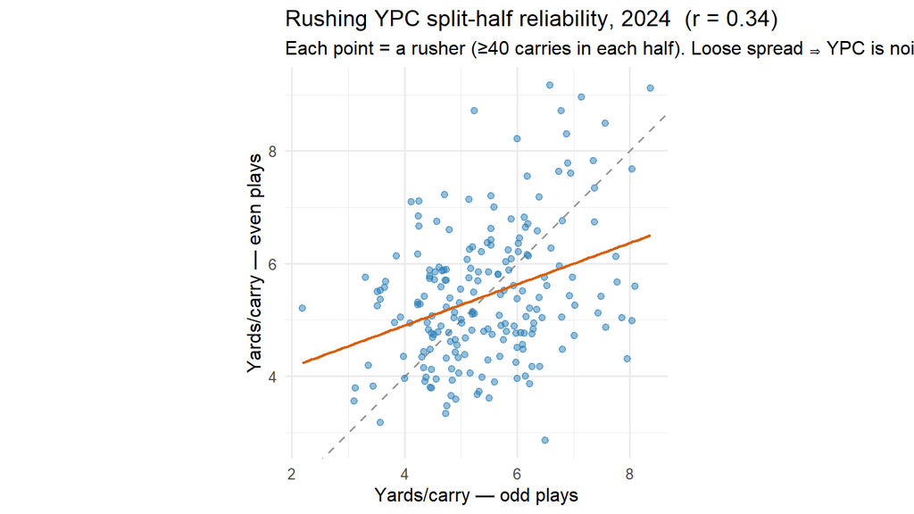

Reliability of rushing YPC

R and Python agree

| Metric | Season(s) | n | R | Python |
| --- | --- | --- | --- | --- |
| Split-half reliability (Spearman-Brown) | 2023 | 212 | 0.547 | 0.547 |
| Split-half reliability (Spearman-Brown) | 2024 | 202 | 0.510 | 0.510 |
| Split-half reliability (Spearman-Brown) | 2025 | 54 | 0.454 | 0.454 |
| Year-over-year r | 2023-2024 | 160 | 0.218 | 0.218 |

## Team archetypes (M6) — PCA + k-means

Each team-season’s 7-stat style profile reduced to 2 principal components, then clustered into five archetypes. Efficient, complete teams sit to one side; struggling or one-dimensional teams to the other.

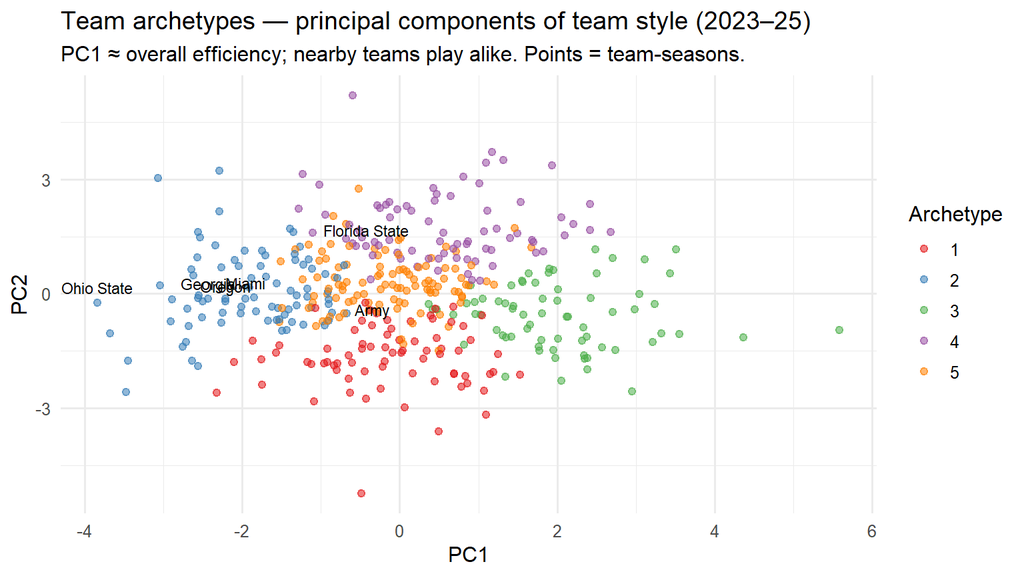

Archetype centroids

Mean style profile per cluster (Def EPA lower = better)

| Archetype | n | Off EPA | Def EPA | Run rate | Pace |
| --- | --- | --- | --- | --- | --- |
| 1 | 75 | −0.011 | 0.014 | 0.58 | 57.42 |
| 2 | 82 | 0.165 | −0.024 | 0.54 | 58.19 |
| 3 | 70 | −0.011 | 0.115 | 0.49 | 53.78 |
| 4 | 76 | 0.171 | 0.153 | 0.50 | 58.52 |
| 5 | 105 | 0.082 | 0.067 | 0.49 | 63.17 |

## Expected points by field position — the EPA foundation

Every efficiency metric here is built on **EPA** (expected points added). This is the expected- points surface it rests on: the mean expected points for a first-and-10 (and later downs) at each spot on the field — from ~6.4 points at the goal line down to *negative* when backed up near your own end zone. The monotonic, football-sensible shape is the sanity check for the whole EPA layer.

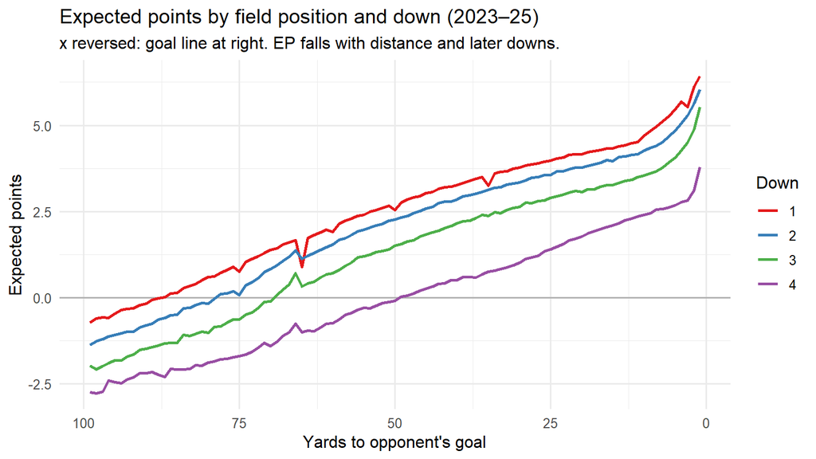

# Part 2 — Evaluating the models

## The game win-probability model

Logistic model of P(home win) from leakage-safe entering-form efficiency differentials. Trained on the earlier seasons (2023–24) and evaluated on the **sealed 2025 holdout** — a season it never saw — against a home-field-naive baseline and the **betting market** (the bar to clear).

2025 holdout accuracy

Lower Brier/log-loss = better; the model approaches the market using on-field efficiency only

| Metric | Model | Market line | Naive (home-field) |
| --- | --- | --- | --- |
| Brier score | 0.191 | 0.176 | 0.243 |
| Log loss | 0.562 | — | — |
| AUC | 0.773 | — | — |
| Accuracy | 0.704 | 0.739 | — |

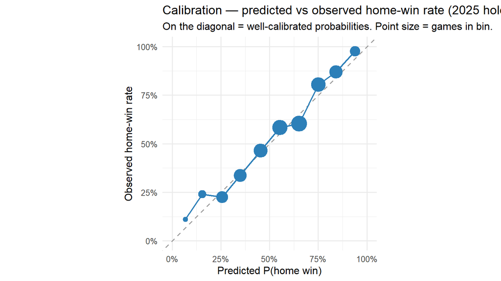

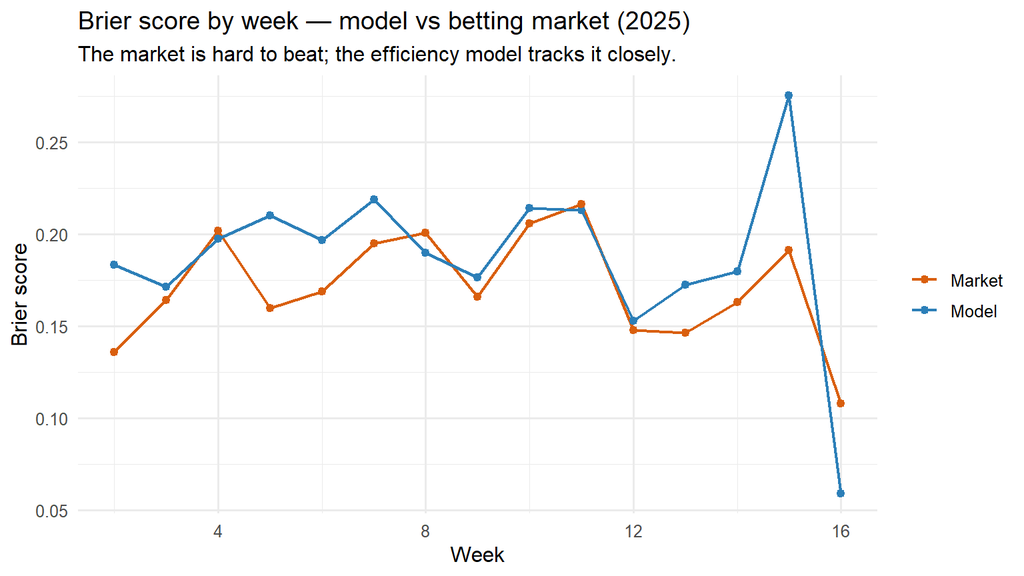

## Forecasting a new season before it starts

The in-season model needs a few weeks of *this year’s* results. To predict **openers** — or a whole schedule the day it drops — a **preseason priors model** uses only *last season’s* carryover (SP+ rating, net EPA, win rate). It’s genuinely useful, but the table below quantifies the honest cost of having no current-year form: preseason forecasts are meaningfully less certain. This is the model that would score a 2026 schedule the moment it’s loaded.

In-season vs preseason forecasting (2025 holdout)

Preseason (prior-year priors only) beats a naive guess but trails the in-season model

[output not shown]

## Model coefficients & fit (M3–M5)

Headline fit metrics by model

| Model | Metric | Value |
| --- | --- | --- |
| ryoe_simple | rmse | 7.7152 |
| ryoe_simple | r_squared | 0.0103 |
| ryoe_multiple | rmse | 7.6845 |
| ryoe_multiple | r_squared | 0.0181 |
| baseline_mean | rmse | 7.7552 |
| cpoe | brier | 0.2344 |
| cpoe | brier_baseline | 0.2365 |
| cpoe | log_loss | 0.6615 |
| passing_td_poisson | dispersion | 0.9476 |
| passing_td_poisson | aic_poisson | 14092.2662 |

## Multilevel shrinkage (M7) — regression to the mean

M1 showed rushing efficiency is noisy; a random-intercept model (`ryoe ~ 1 + (1 | rusher)`) acts on it. Partial pooling pulls each rusher’s raw RYOE toward the league mean — hardest for small-sample rushers. Below, the raw averages (grey) fan out wildly at low volume while the shrunken estimates (blue) stay disciplined; only high-volume backs keep a large signal.

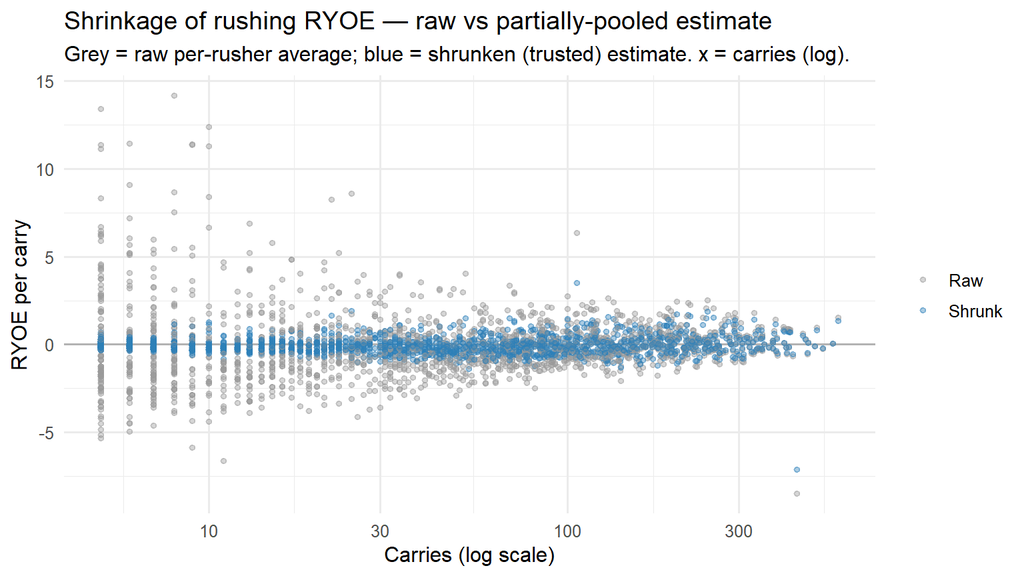

Only **1.2%** of RYOE variance is *between* rushers (the intra-class correlation) — the rest is play-to-play noise. That tiny ICC is exactly why the pooling is so aggressive, and it quantitatively confirms the M1 stability finding.

## Do teams beat their recruiting? (M8)

Recruiting rankings here were collected by **ethically scraping Wikipedia** (CC BY-SA, bot-friendly) — only the *team-level* ranking table, never individual (often minor) recruits — and were validated to match CFBD’s sanctioned recruiting API exactly. Regressing each team’s on-field production (SP+ rating) on its recruiting-class rank shows the expected relationship (better classes → better teams), but the **residuals** are the story: who out- or under-performed the talent they signed.

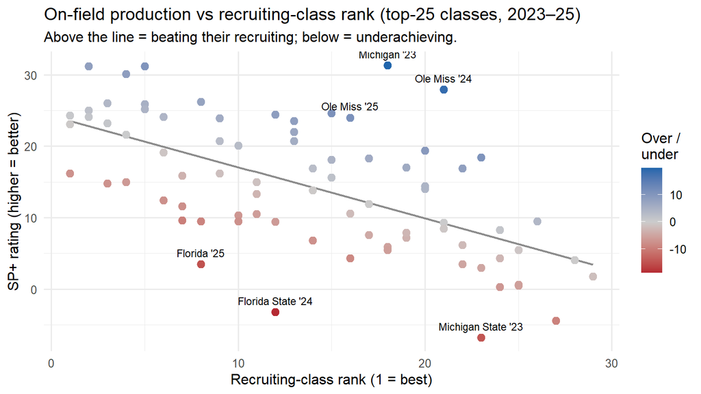

Biggest overachievers vs recruiting

Production well above what their signed talent predicted

| Team | Season | Recruit rank | SP+ | Beat recruiting by |
| --- | --- | --- | --- | --- |
| Michigan | 2023 | 18 | 31.3 | 20.0 |
| Ole Miss | 2024 | 21 | 27.9 | 18.7 |
| Ole Miss | 2025 | 16 | 24.0 | 11.2 |
| Penn State | 2024 | 15 | 24.6 | 11.1 |
| Washington | 2025 | 23 | 18.4 | 10.6 |
| Ohio State | 2024 | 5 | 31.2 | 10.5 |

# Part 3 — 2026 season outlook (a live forecast)

Everything above measures the past; this looks **forward**. Taking the real **2026 schedule** (pulled from CFBD, none of it played yet) and each team’s 2025 carryover, the preseason priors model scores every game, and the per-game probabilities add up to a **projected win total** for each team. Read this as an informed *prior*, not a prophecy: it knows how teams finished 2025 and who they play in 2026, but not transfers, coaching changes, or breakout freshmen — and preseason forecasts are the least certain kind (the accuracy table above quantifies that).

## Projected 2026 win totals

Expected wins summed over each team’s **FBS-vs-FBS** games (cupcake FCS games excluded, so most teams’ real totals run ~1 higher). It blends *team quality* and *schedule*: a strong team with a soft slate projects high; a good team in a brutal division less so.

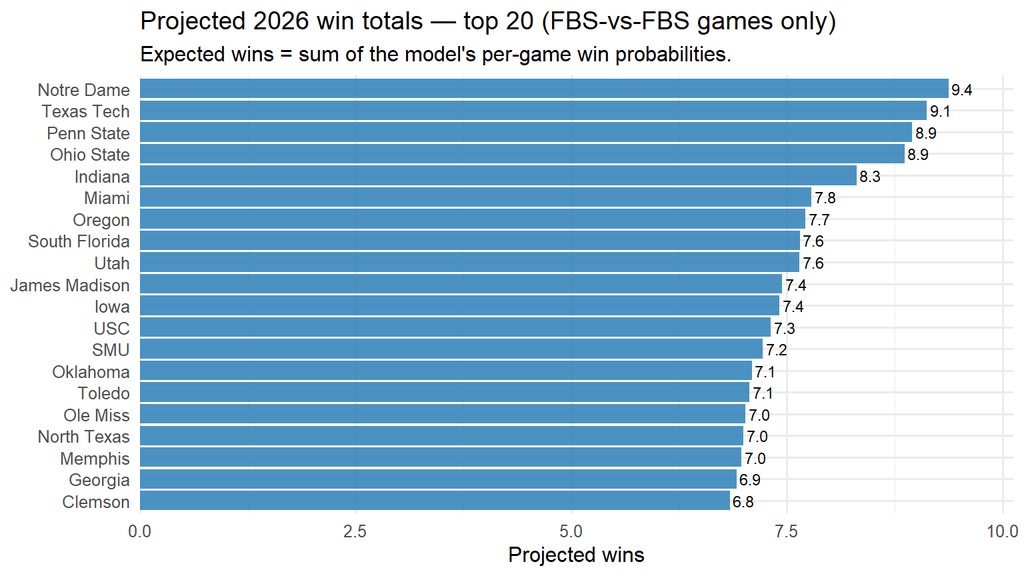

2026 projected win totals — top 25

Preseason priors model applied to the real 2026 schedule

| # | Team | FBS games | Proj. wins | Proj. losses | Avg win prob |
| --- | --- | --- | --- | --- | --- |
| 1 | Notre Dame | 12 | 9.4 | 2.6 | 78% |
| 2 | Texas Tech | 11 | 9.1 | 1.9 | 83% |
| 3 | Penn State | 12 | 8.9 | 3.1 | 75% |
| 4 | Ohio State | 12 | 8.9 | 3.1 | 74% |
| 5 | Indiana | 11 | 8.3 | 2.7 | 76% |
| 6 | Miami | 11 | 7.8 | 3.2 | 71% |
| 7 | Oregon | 11 | 7.7 | 3.3 | 70% |
| 8 | South Florida | 11 | 7.6 | 3.4 | 70% |
| 9 | Utah | 11 | 7.6 | 3.4 | 70% |
| 10 | James Madison | 11 | 7.4 | 3.6 | 68% |
| 11 | Iowa | 11 | 7.4 | 3.6 | 67% |
| 12 | USC | 12 | 7.3 | 4.7 | 61% |
| 13 | SMU | 11 | 7.2 | 3.8 | 66% |
| 14 | Oklahoma | 12 | 7.1 | 4.9 | 59% |
| 15 | Toledo | 10 | 7.1 | 2.9 | 71% |
| 16 | Ole Miss | 11 | 7.0 | 4.0 | 64% |
| 17 | North Texas | 11 | 7.0 | 4.0 | 64% |
| 18 | Memphis | 11 | 7.0 | 4.0 | 63% |
| 19 | Georgia | 11 | 6.9 | 4.1 | 63% |
| 20 | Clemson | 11 | 6.8 | 4.2 | 62% |
| 21 | East Carolina | 11 | 6.8 | 4.2 | 62% |
| 22 | Vanderbilt | 11 | 6.7 | 4.3 | 61% |
| 23 | Washington | 11 | 6.6 | 4.4 | 60% |
| 24 | Virginia | 11 | 6.6 | 4.4 | 60% |
| 25 | Texas A&M | 11 | 6.6 | 4.4 | 60% |

## Opening weekend (week 1)

The model’s closest calls — genuine toss-ups where it has little conviction — and the games it’s most sure about.

Week 1 — the model's true toss-ups

≈50% = a coin flip even to the model

| Matchup | Home win prob | Model leans |
| --- | --- | --- |
| Toledo @ Michigan State | 51% | Michigan State |
| San José State @ Eastern Michigan | 52% | Eastern Michigan |
| UNLV @ Hawai'i | 53% | Hawai'i |
| Western Kentucky @ Nevada | 47% | Western Kentucky |
| Memphis @ UNLV | 46% | Memphis |
| Hawai'i @ Stanford | 46% | Hawai'i |
| UCLA @ California | 55% | California |
| Oklahoma State @ Tulsa | 55% | Tulsa |
| Wyoming @ Colorado State | 55% | Colorado State |
| SMU @ Florida State | 56% | Florida State |

Week 1 — the model's most confident picks

| Matchup | Favorite | Win prob |
| --- | --- | --- |
| Ball State @ Ohio State | Ohio State | 97% |
| Massachusetts @ Rutgers | Rutgers | 92% |
| Kent State @ South Carolina | South Carolina | 92% |
| Northern Illinois @ Iowa | Iowa | 91% |
| Missouri State @ Texas A&M | Texas A&M | 90% |
| UL Monroe @ Mississippi State | Mississippi State | 89% |
| UTEP @ Oklahoma | Oklahoma | 88% |
| San José State @ USC | USC | 87% |

## R ↔︎ Python parity — the built-in correctness check

Every method is fit independently in R and Python on the identical feed. Because the fits are mathematically the same (OLS, IRLS GLM, Poisson, logistic MLE), the coefficients **must** agree. The pipeline’s `load_results` step fails the build if any term diverges beyond tolerance.

R vs Python coefficient agreement

32 coefficients across 9 models · max |Δ| = 1.47e-01

| Model | Term | R | Python | \|Δ\| |
| --- | --- | --- | --- | --- |
| passing_td_negbin | (Intercept) | −2.6343 | −2.7812 | 1.5 × 10<sup>−1</sup> |
| passing_td_negbin | log(pass_attempts) | 0.6920 | 0.7220 | 3.0 × 10<sup>−2</sup> |
| passing_td_negbin | opponent_defense_rating | 0.0254 | 0.0271 | 1.7 × 10<sup>−3</sup> |
| shrinkage | (Intercept) | −0.0468 | −0.0468 | 3.6 × 10<sup>−6</sup> |
| game_winprob | def_epa_diff | −1.3682 | −1.3682 | 1.1 × 10<sup>−7</sup> |
| game_winprob | win_pct_diff | 1.4092 | 1.4092 | 6.0 × 10<sup>−8</sup> |
| game_winprob | roll3_net_epa_diff | 0.7997 | 0.7997 | 4.3 × 10<sup>−8</sup> |
| game_winprob | (Intercept) | 0.3266 | 0.3266 | 2.7 × 10<sup>−8</sup> |
| game_winprob | off_epa_diff | 2.2239 | 2.2239 | 4.0 × 10<sup>−9</sup> |
| game_winprob | sos_diff | 0.0716 | 0.0716 | 1.8 × 10<sup>−9</sup> |
| passing_td_poisson | (Intercept) | −2.6343 | −2.6343 | 1.4 × 10<sup>−10</sup> |
| passing_td_poisson | log(pass_attempts) | 0.6920 | 0.6920 | 3.6 × 10<sup>−11</sup> |

The unsupervised and mixed-effects methods (M6, M7) don’t reduce to a single comparable coefficient — their fits are sign- or label-ambiguous — so agreement is measured label-invariantly:

R vs Python — M6/M7 agreement

1.0 = identical (PCA up to sign; clusters up to labelling)

| Check | Agreement |
| --- | --- |
| M6 · PC1 \|correlation\| | 1.000 |
| M6 · cluster adjusted Rand index | 0.974 |
| M7 · shrunken-estimate correlation | 1.000 |

*Built with R (`gt`, `ggplot2`), Python (`duckdb`, `pandas`), dbt, and DuckDB. Models from Eager & Erickson,* Football Analytics with Python & R*, applied to CFB. Data: CollegeFootballData.com.*